# Aula de Regressão Logística Simples no R

Arthur Lerner

2023-06-22

Este primeiro exemplo tratará da regressão logística simples, portanto, utilizando somente uma variável independente, neste caso numérica.

Trata-se de uma amostra com 100 pessoas. A variável dependente é a ocorrência ou não (1 ou 0) de doença coronária cardíaca (CHD), associando-se com a idade (AGE) dos indivíduos, criando assim um modelo de regressão logística.

**Limpar o R**

```r
rm(list=ls())
```

**Instalar os pacotes caso ainda não tenha instalado** tirar o # da frente de install.packages para funcionar

```r
#Instalando pacotes
#install.packages(c("ggplot2","readr","mfx","caret","pRoc", "ResourceSelection","modEvA","foreign","stargazer", "DataExplorer", "yardstick"))
```

```r
#Carregando pacotes exigidos:
library(readr)
library(dplyr)
library(ggplot2)
library(mfx)
library(caret)
library(pROC)
library(ResourceSelection)
library(modEvA)
library(foreign)
library(stargazer)
library(DataExplorer)
library(yardstick)
library(kableExtra)
```

**Ler os dados** disponíveis na internet

```r
chd <- read_delim("https://github.com/Smolski/livroavancado/raw/master/cdh.csv",
                  ";", escape_double = FALSE, col_types = cols(CHD = col_factor(levels = c())),
                  trim_ws = TRUE)
```

**Visualizar os dados**

```r
kable(head(chd, 10)) %>%
  kable_styling(full_width = F, bootstrap_options = c("striped", "hover", "condensed", "responsive"))
```

| AGE | AGRP | CHD |
| --- | --- | --- |
| 20 | 1 | 0 |
| 23 | 1 | 0 |
| 24 | 1 | 0 |
| 25 | 1 | 0 |
| 25 | 1 | 1 |
| 26 | 1 | 0 |
| 26 | 1 | 0 |
| 28 | 1 | 0 |
| 28 | 1 | 0 |
| 29 | 1 | 0 |

```r
summary(chd)
```

```
##       AGE             AGRP      CHD
##  Min.   :20.00   Min.   :1.00   0:57
##  1st Qu.:34.75   1st Qu.:2.75   1:43
##  Median :44.00   Median :4.00
##  Mean   :44.38   Mean   :4.48
##  3rd Qu.:55.00   3rd Qu.:7.00
##  Max.   :69.00   Max.   :8.00
```

```r
str(chd)
```

```
## spc_tbl_ [100 × 3] (S3: spec_tbl_df/tbl_df/tbl/data.frame)
##  $ AGE : num [1:100] 20 23 24 25 25 26 26 28 28 29 ...
##  $ AGRP: num [1:100] 1 1 1 1 1 1 1 1 1 1 ...
##  $ CHD : Factor w/ 2 levels "0","1": 1 1 1 1 2 1 1 1 1 1 ...
##  - attr(*, "spec")=
##   .. cols(
##   ..   AGE = col_double(),
##   ..   AGRP = col_double(),
##   ..   CHD = col_factor(levels = NULL, ordered = FALSE, include_na = FALSE)
##   .. )
##  - attr(*, "problems")=<externalptr>
```

```r
glimpse(chd)
```

```
## Rows: 100
## Columns: 3
## $ AGE  <dbl> 20, 23, 24, 25, 25, 26, 26, 28, 28, 29, 30, 30, 30, 30, 30, 30, 3…
## $ AGRP <dbl> 1, 1, 1, 1, 1, 1, 1, 1, 1, 1, 2, 2, 2, 2, 2, 2, 2, 2, 2, 2, 2, 2,…
## $ CHD  <fct> 0, 0, 0, 0, 1, 0, 0, 0, 0, 0, 0, 0, 0, 0, 0, 1, 0, 0, 0, 0, 0, 0,…
```

**Mostrar o gráfico de dispersão das observações** Eixo x é idade e eixo y é possui ou não a doença CHD (1 possui e 0 não possui)

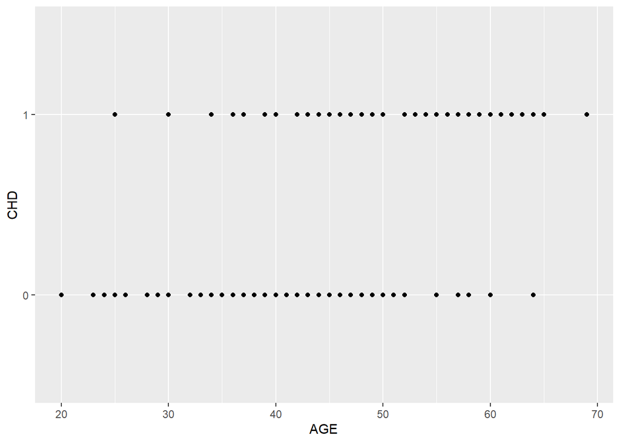

```r
ggplot(chd, aes(x=AGE, y=CHD)) +
  geom_point() +
  stat_smooth(method="glm", method.args=list(family="binomial"), se=FALSE)
```

```r
m1=glm(CHD~AGE, family = binomial(link="logit"), data = chd)
summary(m1)
```

```
##
## Call:
## glm(formula = CHD ~ AGE, family = binomial(link = "logit"), data = chd)
##
## Deviance Residuals:
##     Min       1Q   Median       3Q      Max
## -1.9718  -0.8456  -0.4576   0.8253   2.2859
##
## Coefficients:
##             Estimate Std. Error z value Pr(>|z|)
## (Intercept) -5.30945    1.13365  -4.683 2.82e-06 ***
## AGE          0.11092    0.02406   4.610 4.02e-06 ***
## ---
## Signif. codes:  0 '***' 0.001 '**' 0.01 '*' 0.05 '.' 0.1 ' ' 1
##
## (Dispersion parameter for binomial family taken to be 1)
##
##     Null deviance: 136.66  on 99  degrees of freedom
## Residual deviance: 107.35  on 98  degrees of freedom
## AIC: 111.35
##
## Number of Fisher Scoring iterations: 4
```

Se observa o intercepto com o valor de -5,309, sendo que para a análise aqui proposta da relação entre CHD e AGE não obtém-se um significado prático para este resultado.No entanto, a variável de interesse é idade, que no modelo de regressão obteve o coeficiente de 0,1109. Pelo fato de ser positivo informa que quando a idade (AGE) se eleva, elevam-se as chances de ocorrência de CHD.De igual forma, nota-se que há significância estatística a p = 0,001 na utilização da variável AGE para o modelo, mostrando que possui importância ao modelo de regressão proposto.

```r
# Filtrando a idade dos indivíduos
IDADE<-chd[,1]
```

```r
# Criando campo de predição para cada idade dos indivíduos
chd$PRED=predict(m1, newdata=IDADE, type="response")
```

**Plotando a probabilidade predita pelo modelo**

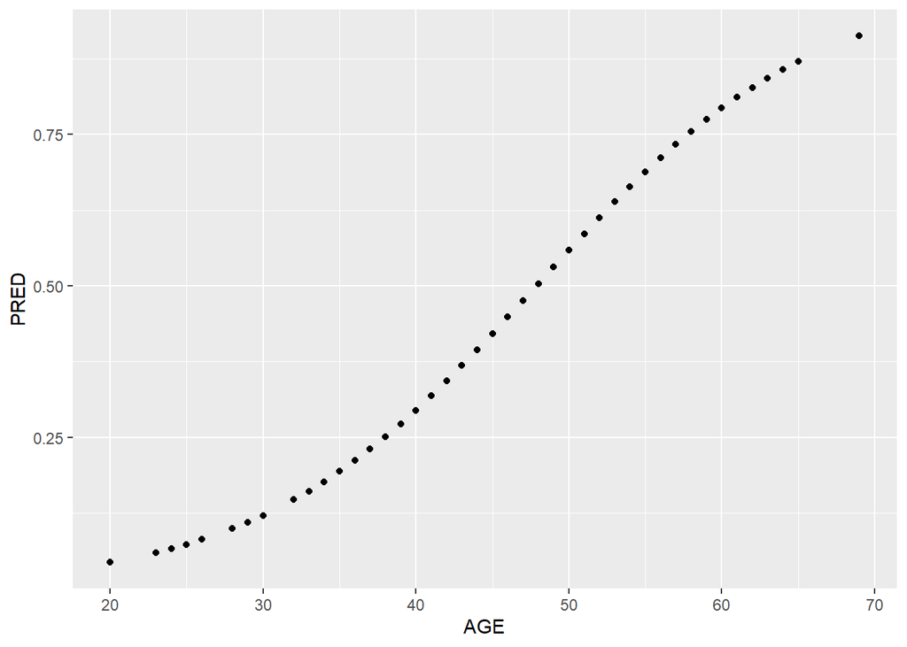

```r
ggplot(chd, aes(x=AGE, y=PRED)) +
  geom_point()
```

**Estimando a Razão de Chances**

```r
logitor(CHD~AGE,data = chd)
```

```
## Call:
## logitor(formula = CHD ~ AGE, data = chd)
##
## Odds Ratio:
##     OddsRatio Std. Err.      z     P>|z|
## AGE  1.117307  0.026882 4.6102 4.022e-06 ***
## ---
## Signif. codes:  0 '***' 0.001 '**' 0.01 '*' 0.05 '.' 0.1 ' ' 1
```

O modelo de regressão logística, porém, traz os resultados dos estimadores na forma logarítma, ou seja, o log das chances da variável idade no modelo é 0,1109. No entanto, para uma interpretação mais enriquecida da relação da idade com o CHD é necessária a transformação deste coeficiente, ou seja, que seja efetuada a exponenciação da(s) variavel(eis) da regressão. Assim, obtém-se a razão das chances (OR - Odds Ratio em inglês) para as variáveis independentes.

Uma maneira prática de se obter a razão de chances no RStudio é utilizando o pacote mfx. Novamente o intercepto não nos interessa nesta análise mas sim a variável AGE. Como demonstrado abaixo, o resultado da razão de chances da variável AGE foi de 1,1173, o que pode assim ser interpretado: para cada variação unitária na idade (AGE), as chances de ocorrência de CHD aumentam 1,1173 vezes. Dito de outra forma, para cada variação unitária em AGE, aumentam-se 11,73% ((1,1173-1)*100) as chances da ocorrência de CHD.

**Determinando o Intervalo de Confiança**

```r
exp(cbind(OR=coef(m1), confint(m1)))
```

```
##                      OR        2.5 %    97.5 %
## (Intercept) 0.004944629 0.0004412621 0.0389236
## AGE         1.117306795 1.0692223156 1.1758681
```

A determinação do intervalo de confiança do modelo proposto é relevante para que seja analizada a estimativa do intervalo de predição do coeficiente da variável independente, a um nível de confiança de 95%. Desta forma, em 95% dos casos, o parâmetro dos coeficientes estará dentro deste intervalo.

De forma prática é possível determinar os intervalos de confiança com o comando confint() commo observado abaixo, sendo que o coeficiente AGE toma o valor de 1,1173, podendo variar de 1,0692 a 1,1758.

**Predição de Probabilidades**

```r
media = data.frame(AGE=mean(chd$AGE))
media
```

```
##     AGE
## 1 44.38
```

A partir dos coeficientes do modelo de regressão logística é possível, portanto, efetuar a predição da variável categórica CHD, ou seja, saber a chance de ocorrer CHD com relação à uma determinada idade (AGE). No exemplo abaixo, primeiramente utilizamos a idade média das observações (44,38 anos), criando assim um novo data.frame chamado media.

```r
media$pred.prob = predict(m1, newdata=media, type="response")
media
```

```
##     AGE pred.prob
## 1 44.38 0.4044944
```

Para utilizar o valor da idade média na função de regressão obtida (m1), utiliza-se a função predict(), de acordo com valor da média encontrada (data.frame media).

O resultado mostra que para a idade média da amostra, 44,38 anos, há uma probabilidade de 40,44% na ocorrência da doença CHD. Esta ferramenta permite também a comparação pelo pesquisador das diferentes probabilidades entre as diversas idades (variável AGE).

**Matriz de Confusão**

```r
chd$pdata <- as.factor(
  ifelse(
    predict(m1,
            newdata = chd,
            type = "response")
    >0.5,"1","0"))

caret::confusionMatrix(chd$pdata, chd$CHD, positive="1")
```

```
## Confusion Matrix and Statistics
##
##           Reference
## Prediction  0  1
##          0 45 14
##          1 12 29
##
##                Accuracy : 0.74
##                  95% CI : (0.6427, 0.8226)
##     No Information Rate : 0.57
##     P-Value [Acc > NIR] : 0.0003187
##
##                   Kappa : 0.4666
##
##  Mcnemar's Test P-Value : 0.8445193
##
##             Sensitivity : 0.6744
##             Specificity : 0.7895
##          Pos Pred Value : 0.7073
##          Neg Pred Value : 0.7627
##              Prevalence : 0.4300
##          Detection Rate : 0.2900
##    Detection Prevalence : 0.4100
##       Balanced Accuracy : 0.7319
##
##        'Positive' Class : 1
##
```

A matriz de confusão retoma uma excelente acurácia total do modelo em 74%, sendo que o modelo consegue acertos de 70,7% na predição de valores positivos ou dos “eventos” (29/41) e 76,3% na predição de valores negativos ou os “não eventos” (45/59).

**Curva ROC**

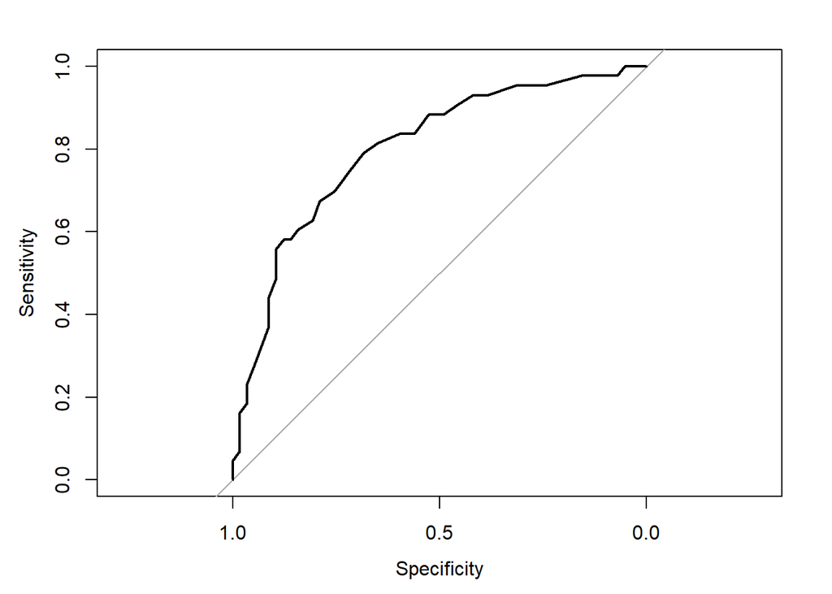

```r
roc1=plot.roc(chd$CHD,fitted(m1))
```

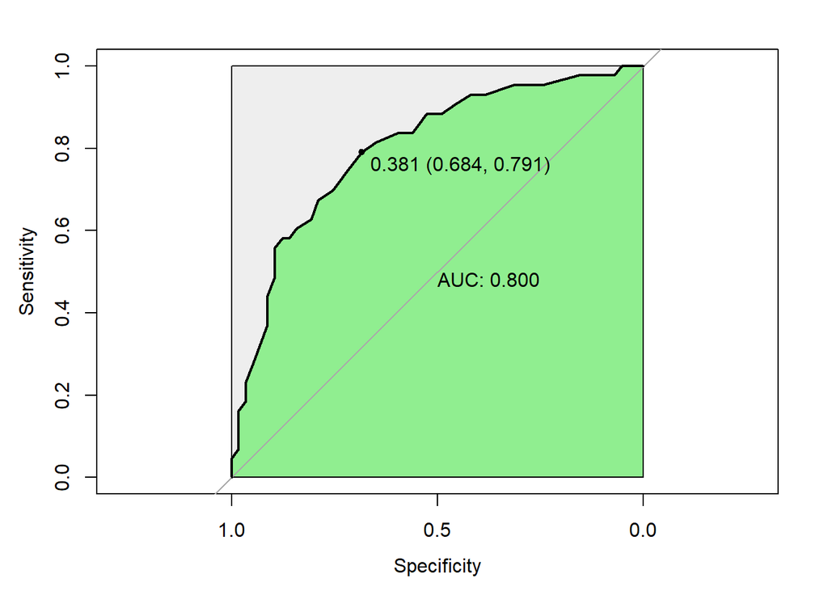

```r
plot(roc1,
     print.auc=TRUE,
     auc.polygon=TRUE,
     grud=c(0.1,0.2),
     grid.col=c("green","red"),
     max.auc.polygon=TRUE,
     auc.polygon.col="lightgreen",
     print.thres=TRUE)
```

**O teste Hosmer e Lemeshow**

```r
hl=hoslem.test(chd$CHD,fitted(m1),g=10)
hl
```

```
##
##  Hosmer and Lemeshow goodness of fit (GOF) test
##
## data:  chd$CHD, fitted(m1)
## X-squared = 100, df = 8, p-value < 2.2e-16
```

O teste de Hosmer e Lemeshow é utilizado para demonstrar a qualidade do ajuste do modelo, ou seja, se o modelo pode explicar os dados observados. Para este teste, os dados são divididos de acordo com as probabilidades previstas em 10 grupos iguais, sendo que os números previstos e os reais são comparados com a estatística do qui-quadrado. Hair et al. (2009) sugerem um tamanho de amostra de pelo menos 50 casos para a realização deste teste.

A hipótese nula H0 do qui-quadrado (p=0,05) deste teste é a de que as proporções observadas e esperadas são as mesmas ao longo da amostra. O modelo apresenta dificuldade de ajuste em função de que rejeita a hipótese nula a p=0,05.

Um grande valor de qui-quadrado (com pequeno valor de p < 0,05) indica um ajuste ruim e pequenos valores de qui-quadrado (com maior valor de p próximo a 1) indicam um bom ajuste do modelo de regressão logística.

**Pseudo R2**

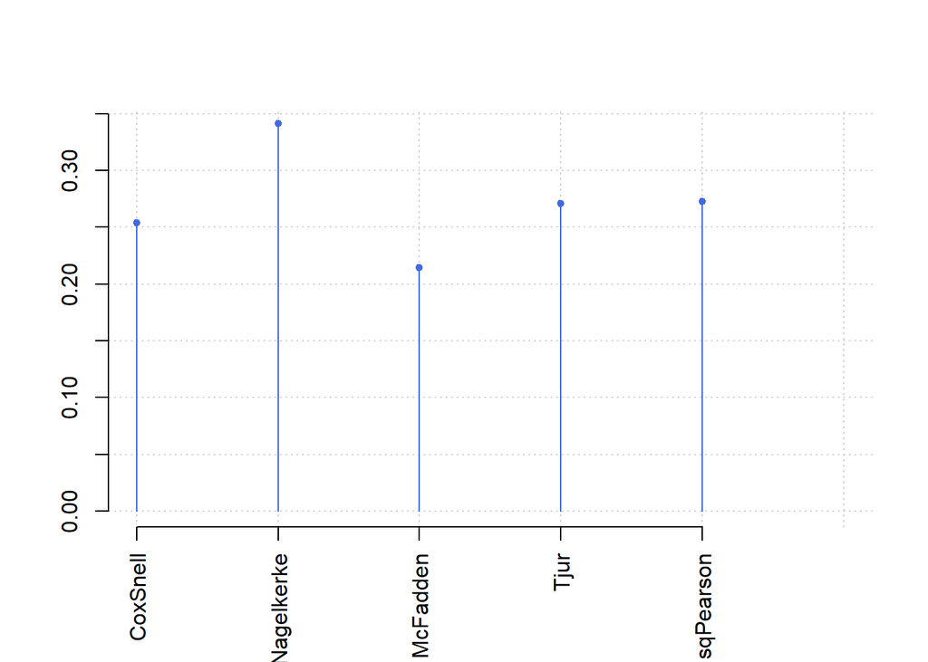

```
## $CoxSnell
## [1] 0.2540516
##
## $Nagelkerke
## [1] 0.3409928
##
## $McFadden
## [1] 0.2144684
##
## $Tjur
## [1] 0.2705749
##
## $sqPearson
## [1] 0.2725518
```

```r
RsqGLM(m1)
```

Semelhante ao coeficiente de determinação R2 da regressão múltipla, a medida de pseudo R2 representam o ajuste geral do modelo proposto. Sua interpretação, portanto, é semelhante à regressão múltipla.

O modelo CoxSnell, por exemplo,explica 25% da variação na variável dependente. No entanto, é chamado de pseudo porque não é exatamente o R2 da regressão linear.